# Where the SHAP Disagreement Actually Lives

- Show All Code
- Hide All Code
- View Source

Not the model — one post-hoc aggregation step, checked against Lundberg et al. and the group-Shapley literature

Author

Net Zero Industrial Policy Lab (NZIPL) · Johns Hopkins SAIS

Published

July 31, 2026

```r
library(readr); library(dplyr); library(tidyr); library(tibble)
library(knitr); library(ggplot2); library(showtext)
font_add_google("Archivo", "Archivo"); showtext_auto(); showtext_opts(dpi = 200)

CATS <- c("Chemicals","Electronics","Industrial Materials","Machinery","Metals")
feat <- read_csv(here::here("data/pc/pc_features.csv"), show_col_types = FALSE)

theme_nr <- function(...) {
  theme_minimal(base_family = "Archivo", base_size = 12) +
    theme(plot.title    = element_text(size = 14, face = "bold", color = "#073309"),
          plot.subtitle = element_text(size = 11, color = "#475569"),
          panel.grid.minor = element_blank(), ...)
}
theme_set(theme_nr())
NZ_DARK <- "#073309"; NZ_GREEN <- "#3cb54a"; NZ_LIGHT <- "#f0f7f0"; NZ_AMBER <- "#f59e0b"
```

> **What this is.** A narrow companion to `model_critical_review.qmd`. That document audits the capability model broadly (macro features, thresholds, the RCA target). This one isolates a single question: **is the arithmetic performed on the SHAP output — after the Random Forest and SHAP have already run — standard practice, and if not, what does the methods literature actually say instead?** It does not revisit whether SHAP or the RF target are appropriate; that part of the model is not in dispute.

> **Bottom line.** Ishana is correct that summing feature-level SHAP magnitudes into a group score has a theoretical basis in the literature. She is not correct that it applies here unmodified. The theorem that licenses summing (i) requires the values being summed to still carry SHAP’s additive/efficiency property, which the **z-scoring step destroys** before the sum ever happens, and (ii) is only exact under **feature independence**, which HS-6 codes inside one capability cluster — co-exported, complementary industrial inputs — are unlikely to satisfy. Neither condition holds for the shipped pipeline.

# 1 Scope: the one step in dispute

The Random Forest, the binary RCA>1 target, and the use of SHAP to explain it are **not** what this document is about. The dispute is confined to one arrow in the pipeline below — everything left of it is common ground:

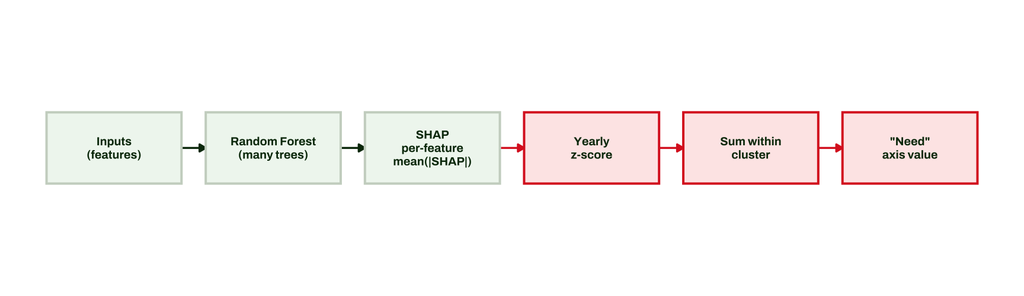

Figure 1: Common ground (grey) vs. the disputed step (red). The RF, the SHAP computation, and even per-feature mean(|SHAP|) are standard. The disagreement starts at the z-score, and compounds at the sum.

```r
W <- 1.95; H <- 0.9
bx <- tibble(
  cx = seq(1, by = 2.3, length.out = 6), cy = 0,
  label = c("Inputs\n(features)", "Random Forest\n(many trees)",
            "SHAP\nper-feature\nmean(|SHAP|)", "Yearly\nz-score",
            "Sum within\ncluster", "\"Need\"\naxis value")) |>
  mutate(xmin = cx - W/2, xmax = cx + W/2, ymin = cy - H/2, ymax = cy + H/2,
         disputed = row_number() >= 4,
         fill = ifelse(disputed, "#fde8e8", NZ_LIGHT),
         border = ifelse(disputed, "#dc2626", "#cbd5c9"),
         txt  = NZ_DARK)
arr <- tibble(x = bx$xmax[1:5], xend = bx$xmin[2:6], y = 0,
              disputed = seq_len(5) >= 3)
ggplot() +
  geom_segment(data = arr, aes(x, y, xend = xend, yend = y,
                                colour = ifelse(disputed, "#dc2626", NZ_DARK)),
               arrow = arrow(length = unit(0.16, "cm"), type = "closed"), linewidth = 0.6) +
  geom_rect(data = bx, aes(xmin = xmin, xmax = xmax, ymin = ymin, ymax = ymax,
                           fill = fill, colour = border), linewidth = 0.7) +
  geom_text(data = bx, aes(cx, cy, label = label, colour = txt),
            family = "Archivo", fontface = "bold", size = 2.6, lineheight = 0.95) +
  scale_fill_identity() + scale_colour_identity() +
  coord_cartesian(ylim = c(-1.7, 1.7), clip = "off") + theme_void()
```